# Test a Perceptual Phenomenon

Udacity Nanodegree Data Analyst Project 1

Daniel Pöhle

Monday, September 07, 2015

## Introduction

In this paper, the reaction times of some participants doing the **stroop task** will be analyzed. Te participants had to name the color of words in two different scenarios. On the one hand, the actual word does not match the printed color and on the other hand both information correspond to each other. It will be analyzed if the congruent or incongruent information has an influence on the reaction times of the task (further details on wikipedia: [Stroop effect](https://en.wikipedia.org/wiki/Stroop_effect)).

The provided sample data contains 24 participants who took the stroop task ([Data Source](https://drive.google.com/file/d/0B9Yf01UaIbUgQXpYb2NhZ29yX1U/view)). For each participant the reaction time in seconds for the congruent and incongruent task was recorded.

## Question 1

**What is the independent variable? What is the dependent variable?**

The independent variable is the type of task (congruent or incongruent). The dependent variable is the reaction time for completing the stroop task.

## Question 2

**What is an appropriate set of hypotheses for this task? What kind of statistical test do you expect to perform? Justify your choices.**

Null hypothesis: The reaction times for both tasks are the same in the population.

Alternative Hypothesis: The reaction times for boths tasks are different in the population.

We presume that there is a difference in reaction times in the population because incongruent information are harder to handle intellectually. We can prove the assumption if we are able to reject the null hypothesis. The probability that reaction times for both tasks in the population are the same and the observed reaction times in the sample differ only accidentally will be at most $\alpha = 5\%$.

We will use a dependent two-sided t-test for paired samples in the statistical analysis.The samples in the experiment are dependent because the same participants have been tested with both stroop tasks. We take the average and standard deviation of the differences in reaction times and test if it is significantly different from zero. The difference will be zero, if both reaction times are the same in the population.

## Question 3

**Report some descriptive statistics regarding this dataset. Include at least one measure of central tendency and at least one measure of variability.**

```r
stroopData <- read.csv(file = "./stroopdata.csv", stringsAsFactors = F)
meanCongruent <- mean(stroopData$Congruent)
stdDevCongruent <- sd(stroopData$Congruent)

meanIncongruent <- mean(stroopData$Incongruent)
stdDevIncongruent <- sd(stroopData$Incongruent)

n <- length(stroopData[,1])
```

| Measure | Congruent | Incongruent |
| --- | --- | --- |
| Average Reaction Time [sec] | 14.051125 | 22.0159167 |
| Standard Deviation Reaction Time [sec] | 3.559358 | 4.7970571 |

## Question 4

**Provide one or two visualizations that show the distribution of the sample data. Write one or two sentences noting what you observe about the plot or plots.**

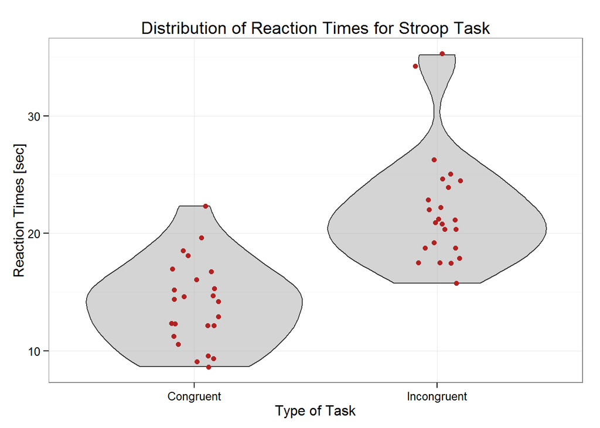

```r
stroopData2 <- stroopData
stroopData2$ID <- as.factor(c(1:length(stroopData$Congruent)))
stroopData2 <- melt(data = stroopData2)
ggplot(stroopData2, aes(x=variable, y=value)) + theme_bw() + geom_violin(alpha=0.5, fill="darkgray") +
geom_jitter(color = "firebrick", position = position_jitter(w = 0.1, h = 0.1)) +
xlab("Type of Task") +  ylab("Reaction Times [sec]") +
ggtitle("Distribution of Reaction Times for Stroop Task")
```

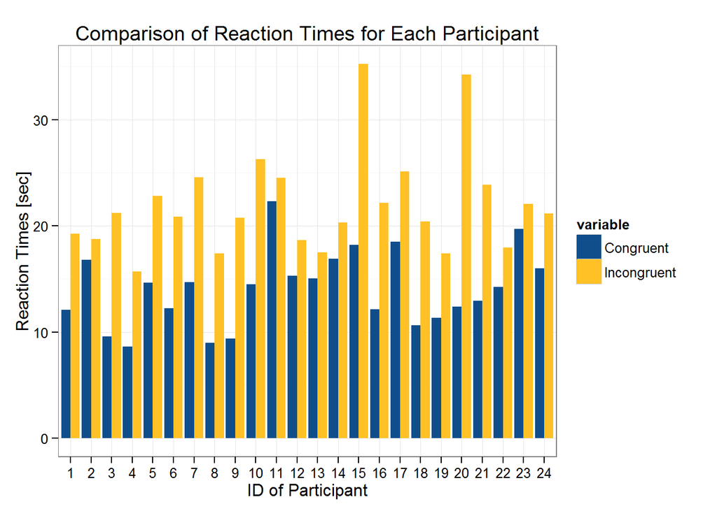

```r
ggplot(stroopData2, aes(x = ID, y = value, fill=variable)) + geom_bar(stat="identity", position="dodge") + theme_bw() +
scale_fill_manual(values = c("dodgerblue4", "goldenrod1")) +
xlab("ID of Participant") +  ylab("Reaction Times [sec]") +
ggtitle("Comparison of Reaction Times for Each Participant")
```

In this barplot there is a direct comparison of reaction times for each participant of the sample. The reaction times for the task with incongruent information are greater than the reaction times for the task with congruent information in all cases of the sample.

## Question 5

**Now, perform the statistical test and report your results. What is your confidence level and your critical statistic value? Do you reject the null hypothesis or fail to reject it? Come to a conclusion in terms of the experiment task. Did the results match up with your expectations?**

```r
######### Dependent t-test for paired samples #########
difference <- stroopData$Congruent - stroopData$Incongruent
meanDifference <- mean(difference)
stdDevDifference <- sd(difference)
standardError <- stdDevDifference / sqrt(n)

t <- abs(meanDifference / standardError)
alpha <- 0.05
df <- n-1
tCritical <- qt(1-alpha/2, df)
```

| Variable | Value |
| --- | --- |
| Mean Difference [sec] | -7.9647917 |
| Standard Error of Difference [sec] | 0.9930286 |
| t-Statistic | 8.0207069 |
| Degrees of Freedom | 23 |
| t-Critical Value at $\alpha = 5\%$ | 2.0686576 |

The results of the statisitcal test confirm the observations in the violin plot of question 4 and match the expectations at the beginning. Consequently, the participants need longer reaction times for the stroop task if color and word are incongruent.

## Question 6

**Optional: What do you think is responsible for the effects observed? Can you think of an alternative or similar task that would result in a similar effect? Some research about the problem will be helpful for thinking about these two questions!**

Generally, it is plausible that a participant can name the color of a word easier if the actual word is congruent to the color. The participant will just read out the written words instead of paying attention to the colors when he / she realizes that both information always match. When the word does not match the color, the participant has to distinguish the color of the word and must not be confused by the word he / she reads. Hence the process of naming the incongruent colors is more complex and requires more time.

An alternative similar stroop test would be to name the location (left, right, up, down) of the word “left” within a rectangle (see [Interactive “Directional Stroop” Effect Experiment](https://faculty.washington.edu/chudler/java/readyd.html)). In three out of four cases the information are incongruent.

## Sources

- [Data Set](https://drive.google.com/file/d/0B9Yf01UaIbUgQXpYb2NhZ29yX1U/view)
- [Neuroscience For Kids](https://faculty.washington.edu/chudler/words.html)
- [Paired Difference Test, Article Wikipedia](https://en.wikipedia.org/wiki/Paired_difference_test)
- [R Markdown Cheatsheet](https://www.rstudio.com/wp-content/uploads/2015/02/rmarkdown-cheatsheet.pdf)
- [Stroop Effect, Article Wikipedia](https://en.wikipedia.org/wiki/Stroop_effect)